### Part I

#### OPEN BOOK

Tuesday, November 19, 2013

**1.** An entomologist counted the number eggs laid by female moths on successive days from each of 25 matings in four strains of tobacco budworm. The dataset `counts.txt` contains the number of eggs (counts) laid on the third day after the mating for each female in each of the strains. You can assume the samples are random samples.

```r
# Read in data
raw.text <- "
Counts Strain
    0  1
    0  1
   22  1
    3  1
   17  1
    0  1
    0  1
    7  1
   11  1
   11  1
   73  1
   33  1
    0  1
   65  1
   13  1
   44  1
   20  1
   27  1
   48  1
  104  1
  233  1
   81  1
   22  1
    9  1
    2  1
    0  2
    0  2
   56  2
    0  2
    8  2
    0  2
    3  2
    1  2
   16  2
   55  2
  142  2
   10  2
    2  2
  145  2
    6  2
    4  2
    5  2
  124  2
   24  2
  204  2
  415  2
  466  2
    6  2
   14  2
   12  2
    0  3
    0  3
    4  3
   13  3
    5  3
    1  3
    1  3
    4  3
    4  3
   36  3
  407  3
    0  3
    0  3
   18  3
    4  3
   14  3
    0  3
   24  3
   52  3
  314  3
  245  3
  107  3
    5  3
    6  3
    2  3
    0  4
    0  4
    0  4
    4  4
    2  4
    2  4
    5  4
    4  4
    2  4
    1  4
    0  4
   12  4
    1  4
   30  4
    0  4
    3  4
   28  4
    2  4
   21  4
    8  4
   82  4
   12  4
   10  4
    2  4
    0  4
"
moth.df <- read.table(header=TRUE, text=raw.text)
moth.df$Strain <- factor(moth.df$Strain) # convert Strain into a factor variable
```

1. [7 points] What is the name of the experimental design? Run the corresponding ANOVA model and do assumption diagnostics and write a conclusion for each assumption.  
   **Solution**  
   “This design is called completely randomized design (one-way ANOVA). Running a one-way ANOVA with the response Counts and the fixed factor Strain we get the following ANOVA table and residual plots:”

```r
moth.aov <- aov(formula=Counts ~ Strain, data=moth.df)
summary(moth.aov)
```

```
##             Df Sum Sq Mean Sq F value Pr(>F)
## Strain       3  48031   16010   2.128  0.102
## Residuals   96 722337    7524
```

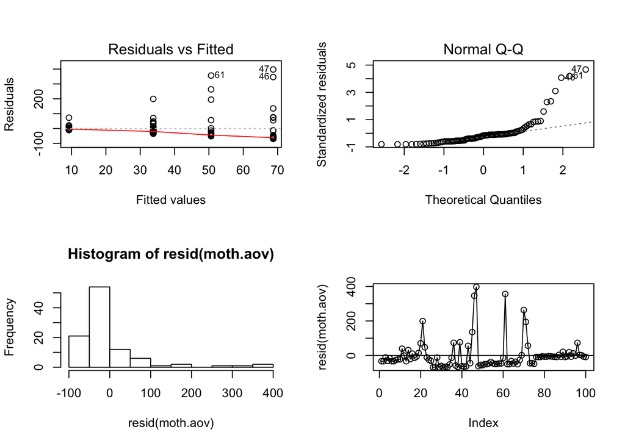

```r
par(mfrow=c(2, 2)) # Creating 2X2 layout for plots
plot(x=moth.aov, which=1) # residual vs. fitted
plot(x=moth.aov, which=2) # QQ Plot
hist(x=resid(moth.aov))   # histogram of residuals
plot(x=resid(moth.aov), type="o"); abline(h=0) # residual vs. order of data (row number)
```

```r
par(mfrow=c(1, 1)) # Returning to default settings: 1X1 layout
```

“From looking at the residual plots it appears that several assumptions are being violated. In particular it looks like the residuals are not normal and that the variance is not constant.” (Solutions provide a plot measuring equality of variance.)

```r
library(nortest)
ad.test(x=resid(moth.aov)) # test for normality
```

```
##
##  Anderson-Darling normality test
##
## data:  resid(moth.aov)
## A = 10.9321, p-value < 2.2e-16
```

```r
# Test for equality of variances
bartlett.test(formula=Counts ~ Strain, data=moth.df)
```

```
##
##  Bartlett test of homogeneity of variances
##
## data:  Counts by Strain
## Bartlett's K-squared = 73.9977, df = 3, p-value = 5.942e-16
```

```r
library(car)
# Test for equality of variances
leveneTest(y=moth.df$Counts, group=moth.df$Strain, center=median)
```

```
## Levene's Test for Homogeneity of Variance (center = median)
##       Df F value  Pr(>F)
## group  3  2.1665 0.09698 .
##       96
## ---
## Signif. codes:  0 '***' 0.001 '**' 0.01 '*' 0.05 '.' 0.1 ' ' 1
```

“The Anderson-Darling test for normality has a *p*-value of < 0.005 which means at $\alpha = 0.05$ we can reject $H_0$ that the residuals are normally distributed. Bartlett’s and Levene’s tests for equal variance have *p*-values of 0.000 and 0.097 respectively. So at $\alpha = 0.10$ we can reject $H_0$ that the residuals have equal variance.”

2. [7 points] Do a natural log transformation adding $0.5$ on “counts,” i.e. the response becomes *ln(counts + 0.5)*. Use the transformed response and part (a) again. Why is it inappropriate to use *ln(counts)*?  
   **Solution**

```r
moth.df$log_counts <- log(moth.df$Counts + 0.5)
moth.log.aov <- aov(formula=log_counts ~ Strain, data=moth.df)
summary(moth.log.aov)
```

```
##             Df Sum Sq Mean Sq F value Pr(>F)
## Strain       3   24.8   8.278   2.281 0.0841 .
## Residuals   96  348.4   3.629
## ---
## Signif. codes:  0 '***' 0.001 '**' 0.01 '*' 0.05 '.' 0.1 ' ' 1
```

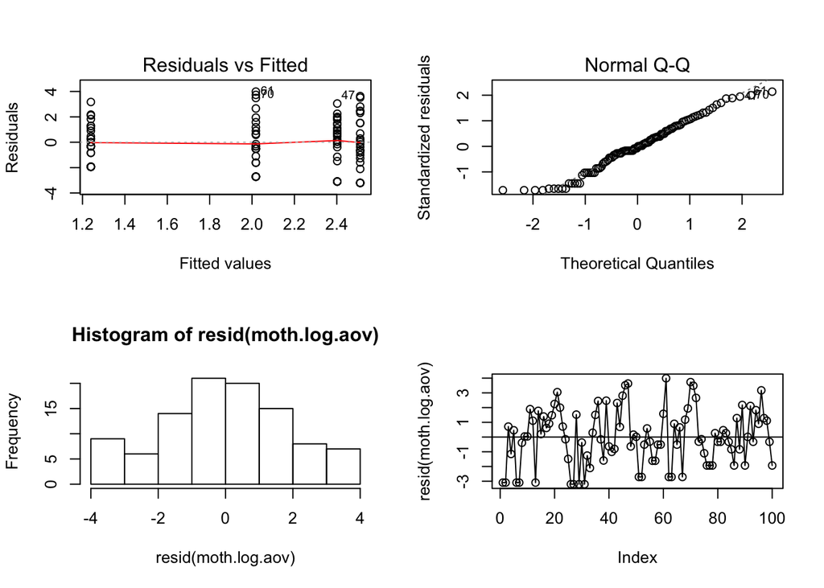

```r
par(mfrow=c(2, 2)) # Creating 2X2 layout for plots
plot(x=moth.log.aov, which=1) # residual vs. fitted
plot(x=moth.log.aov, which=2) # QQ Plot
hist(x=resid(moth.log.aov))   # histogram of residuals
plot(x=resid(moth.log.aov), type="o"); abline(h=0) # residual vs. order of data (row number)
```

```r
par(mfrow=c(1, 1)) # Returning to default settings: 1X1 layout
```

“The residual plots from the transformed response look much better. Just from looking at the plots it appears that no assumptions are being violated.” (Solutions provide a plot measuring equality of variance.)

```r
library(nortest)
ad.test(x=resid(moth.aov)) # test for normality
```

```
##
##  Anderson-Darling normality test
##
## data:  resid(moth.aov)
## A = 10.9321, p-value < 2.2e-16
```

```r
# Test for equality of variances
bartlett.test(formula=Counts ~ Strain, data=moth.df)
```

```
##
##  Bartlett test of homogeneity of variances
##
## data:  Counts by Strain
## Bartlett's K-squared = 73.9977, df = 3, p-value = 5.942e-16
```

```r
library(car)
# Test for equality of variances
leveneTest(y=moth.df$Counts, group=moth.df$Strain, center=median)
```

```
## Levene's Test for Homogeneity of Variance (center = median)
##       Df F value  Pr(>F)
## group  3  2.1665 0.09698 .
##       96
## ---
## Signif. codes:  0 '***' 0.001 '**' 0.01 '*' 0.05 '.' 0.1 ' ' 1
```

“We can’t use ln(Counts) as the response because there are observations were Counts = 0 and the ln(0) cannot be calculated.”

3. [4 points] Are there significant differences among the four strains in the number of eggs per female moth?  
   **Solution**  
   “From the ANOVA table in part (b) we see a *p*-value of 0.084. So at $\alpha=0.10$ we can reject $H_0$ that all four strains are the same. That is, there is a marginally significant difference among the four strains in the number of eggs per female moth.”
4. [7 points] The entomologist would like to identify the strain of which the moth population will increase fastest given that mating rates for four strains are equal. Conduct pairwise comparisons to find the best (subset of) strain and the experimentwise error rate must be controlled at 10%.  
   **Solution**

```r
TukeyHSD(x=moth.log.aov, conf.level=0.90)
```

```
##   Tukey multiple comparisons of means
##     90% family-wise confidence level
##
## Fit: aov(formula = log_counts ~ Strain, data = moth.df)
##
## $Strain
##           diff       lwr         upr     p adj
## 2-1  0.1082329 -1.143231  1.35969646 0.9971111
## 3-1 -0.3839733 -1.635437  0.86749027 0.8918524
## 4-1 -1.1624439 -2.413907  0.08901963 0.1427149
## 3-2 -0.4922062 -1.743670  0.75925734 0.7976758
## 4-2 -1.2706768 -2.522140 -0.01921331 0.0922820
## 4-3 -0.7784706 -2.029934  0.47299289 0.4748219
```

2 and 4 are different.